# Predicting Subscribed Users In A Marketing Campaign

## Phase 2: Predictive Modelling

### Group Name: 60

### Names And IDs of Group members:

Vedanth Sujay Prasad, s4041704  
Himanshu Jindal, s3971520  
Pratham Radhakrishna, s3997064

- Introduction
  - Phase 1 Summary
  - Report Overview
  - Overview of Methodology
- Predictive Modelling
  - Feature Selection (FS)
  - Model Fitting & Tuning
  - Model Comparison
- Critique & Limitation
- Summary & Conclusions
  - Project Summary
  - Summary of Findings
  - Conclusions

## Introduction

In today's financial institution scene, direct marketing efforts are critical for engaging new clients and developing long-term connections. Phone-based marketing campaigns have become a common technique for many firms, including Portuguese financial institutions. Among these institutions, the effectiveness of such campaigns is assessed not only by the number of contacts, but also by the conversion of these interactions into tangible outcomes, such as term deposit subscriptions.

The Bank Marketing dataset is a significant data repository that provides insights into the dynamics of a Portuguese financial organization's direct marketing initiatives. This dataset has 21 unique variables and 41,188 entries, capturing a complex tapestry of consumer demographics, marketing information, and subscription results.Moro,S., Rita,P., and Cortez,P.. (2012)

At its heart, the dataset provides a comprehensive perspective of the customer base, including demographic data such as age, marital status, education, home loan status, personal loan status, credit default status, and employment type. These characteristics give a more sophisticated knowledge of the target audience, allowing institutions to successfully customize their marketing efforts to specific sectors of the population.

Furthermore, the dataset delves into the complexities of campaign execution, providing insights into the months with the most and least interactions, the contact types used, the number of workers involved, and key economic indicators like the employment variation rate, consumer price index, and consumer confidence index. Organizations may improve overall campaign performance by evaluating campaign specifics.

The goal variable—subscription status—is central to the dataset. This binary indication indicates if a client has agreed to a term deposit as a result of the marketing effort. Understanding the elements that drive subscription outcomes is critical for financial institutions looking to maximize their marketing ROI and build a loyal client base.

Given its range and depth, the dataset is an invaluable resource for scholars, analysts, and industry practitioners. Using the insights gathered from this dataset, stakeholders may improve prediction models, get actionable knowledge, and drive informed decision-making processes. Thus, the Bank Marketing dataset demonstrates the confluence of data-driven approaches with strategic marketing campaigns, providing insight into the changing landscape of customer interaction and subscription results in the banking industry.

### Phase 1 Summary

The Bank Marketing dataset includes information about direct marketing efforts carried out by a Portuguese financial organization. These programs were mostly phone-based and included a number of factors relating to customer demographics and detailed interactions within marketing activities.

**KEY ATTRIBUTES** - **Demographic Information:** Includes age, marital status, education, housing loan status, personal loan status, credit default status and Job Type. - **Campaign Details:** Months of maximum and minimum interactions, Contact type, number of workers, employment variation rate, consumer price index, consumer confidence index. - **Target Variable:** Subscription Status indicates whether or not the client has subscribed to a term deposit.

**Details**

- **Name:** Bank Marketing Dataset
- **Features:** 21 attributes
- **Observations:** 41,188 entries

This information is a significant resource for measuring the success of the bank's marketing initiatives, as well as studying customer behavior and subscription outcomes.

Summary:

The Bank Marketing dataset study yielded useful insights on a Portuguese banking institution's direct marketing initiatives. The dataset includes features such as customer demographics, campaign specifics, and subscription outcomes. Key conclusions of the analysis include:

1. Demographic insights:
- The dataset comprises information such as age, marital status, education, employment type, and home loan status, among other things, to provide a complete picture of the client base.
- Customers were segmented based on demographic factors, revealing possible marketing campaign targets.
2. Campaign Performance:
- Analysis of campaign characteristics such as contact methods, months, and days of the week revealed trends in client interaction.
- The analysis of subscription rates across various campaign parameters aided in determining the efficacy of previous marketing initiatives.
3. Economic Indicators: Economic factors such as the employment variation rate, consumer price index, and consumer confidence index were investigated to determine their influence on customer behavior and subscription results.
4. Risk Assessment: Patterns in default credit and loan status were discovered, assisting in the evaluation of credit risk and future default among consumers.

New part for phase 2

In Phase 1 of this project, we focused on understanding the Bank Marketing dataset, which contains information about direct marketing campaigns conducted by a Portuguese financial institution. Our primary tasks involved data exploration, cleaning, and initial analysis. We examined the demographic information of the clients, details of the marketing campaigns, and economic indicators to identify patterns and insights. This foundational work laid the groundwork for the predictive modeling tasks in Phase 2, where we aim to predict whether a client will subscribe to a term deposit based on the available features.

### Overview of Methodology

Our predictive modelling methodology will consist of the following steps:

By following this methodology, we aim to build predictive models that can effectively predict whether a client will subscribe to a term deposit based on their demographic and campaign-related features.

# Data Preparation

For the preparation of our data in Phase 2, we had to create a heatmap to find the the correlation between the variables and remove them along with all the time related variables to start the predictive modelling. Predictive modelling can not take place with time series data and hence it was removed.

The following variablers were removed:

- euribor3m
- nr.employed
- duration
- emp.var.rate
- cons.price.idx
- day_of_week
- month

Following this, the data was split into training and target data sets to start the analysis. One hot encoding was applied to convert the categorical variables into numerical variables to continue the analysis.

The data was then scaled to normalize the values for predictive analysis.

```python
import warnings
warnings.filterwarnings("ignore")

import pandas as pd
import numpy as np
import seaborn as sns
import matplotlib.pyplot as plt
%matplotlib inline
%config InlineBackend.figure_format = 'retina'
plt.style.use("ggplot")

pd.set_option('display.max_columns', None)
```

```python
data = pd.read_csv("Phase2_Group60.csv")
data.head()
```

|  | age | job | marital | education | default | housing | loan | contact | month | day_of_week | duration | campaign | pdays | previous | poutcome | emp.var.rate | cons.price.idx | cons.conf.idx | euribor3m | nr.employed | subscribed |
| --- | --- | --- | --- | --- | --- | --- | --- | --- | --- | --- | --- | --- | --- | --- | --- | --- | --- | --- | --- | --- | --- |
| 0 | 56 | housemaid | married | basic.4y | no | no | no | telephone | may | mon | 261 | 1 | 999 | 0 | nonexistent | 1.1 | 93.994 | -36.4 | 4.857 | 5191.0 | no |
| 1 | 57 | services | married | high.school | unknown | no | no | telephone | may | mon | 149 | 1 | 999 | 0 | nonexistent | 1.1 | 93.994 | -36.4 | 4.857 | 5191.0 | no |
| 2 | 37 | services | married | high.school | no | yes | no | telephone | may | mon | 226 | 1 | 999 | 0 | nonexistent | 1.1 | 93.994 | -36.4 | 4.857 | 5191.0 | no |
| 3 | 40 | admin. | married | basic.6y | no | no | no | telephone | may | mon | 151 | 1 | 999 | 0 | nonexistent | 1.1 | 93.994 | -36.4 | 4.857 | 5191.0 | no |
| 4 | 56 | services | married | high.school | no | no | yes | telephone | may | mon | 307 | 1 | 999 | 0 | nonexistent | 1.1 | 93.994 | -36.4 | 4.857 | 5191.0 | no |

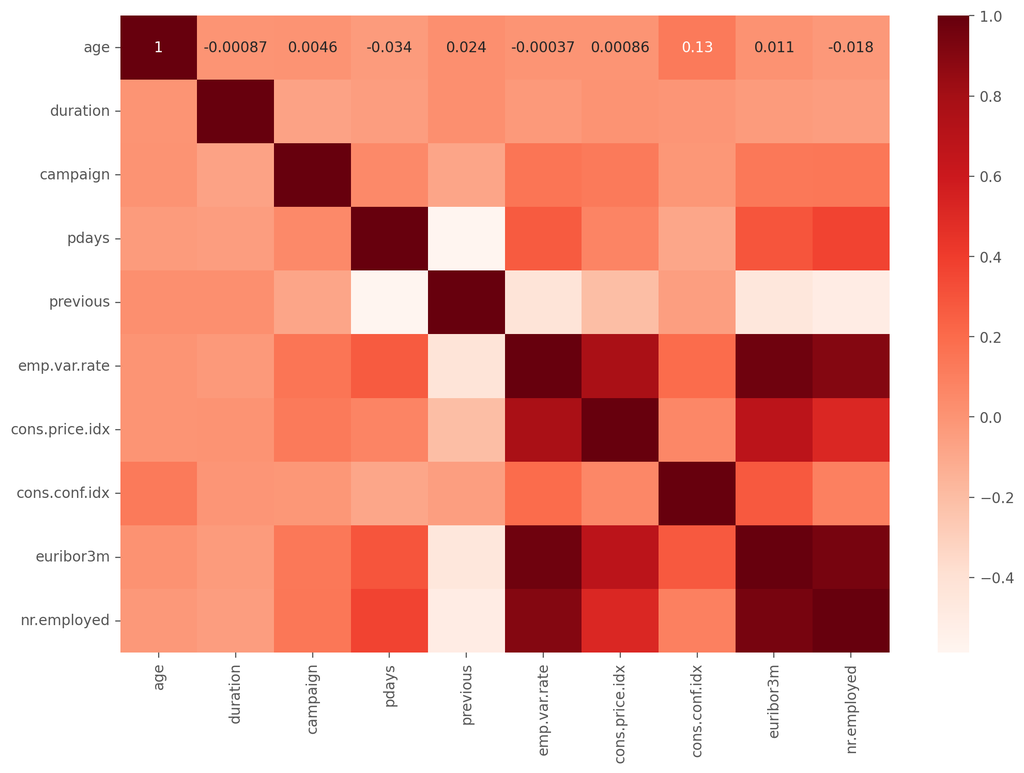

```python
corr_data = data.corr()
plt.figure(figsize=(12,8))
sns.heatmap(corr_data, cmap="Reds", annot=True)
```

```python
data.drop(['euribor3m', 'nr.employed', 'duration', 'emp.var.rate', 'cons.price.idx', 'day_of_week', 'month'], axis=1, inplace=True)
```

# Splitting the Data and Target variables

```python
# Separate features (X) and target variable (y)
X = data.drop(columns=['subscribed'])  # Assuming 'subscribed' is the target variable
y = data['subscribed']
y.value_counts()
```

```
no     36548
yes     4640
Name: subscribed, dtype: int64
```

# One Hot Encoding

```python
# Converting Binary type columns to numerical

binary_cols = ['housing', 'loan', 'subscribed', 'default']
dummy_list = []

for i in binary_cols:
    for text in data[i].values:
        if text == 'yes':
            dummy_list.append(1)
        else:
            dummy_list.append(0)
    data[i] = dummy_list
    dummy_list = []
```

```python
# Converting categorical columns to numerical
categoricalColumns = X.columns[X.dtypes==object].tolist()

for col in categoricalColumns:
    print('Unique values for ' + col)
    print(X[col].unique())
    print('')

for col in categoricalColumns:
    n = len(X[col].unique())
    if (n == 2):
        X[col] = pd.get_dummies(X[col], drop_first=True)

X = pd.get_dummies(X)

from sklearn.preprocessing import LabelEncoder
label_encoder = LabelEncoder()
y = label_encoder.fit_transform(y)
```

```
Unique values for job
['housemaid' 'services' 'admin.' 'blue-collar' 'technician' 'retired'
 'management' 'unemployed' 'self-employed' 'unknown' 'entrepreneur'
 'student']

Unique values for marital
['married' 'single' 'divorced' 'unknown']

Unique values for education
['basic.4y' 'high.school' 'basic.6y' 'basic.9y' 'professional.course'
 'unknown' 'university.degree' 'illiterate']

Unique values for default
['no' 'unknown' 'yes']

Unique values for housing
['no' 'yes' 'unknown']

Unique values for loan
['no' 'yes' 'unknown']

Unique values for contact
['telephone' 'cellular']

Unique values for poutcome
['nonexistent' 'failure' 'success']
```

```python
X.sample(10, random_state=40)
```

|  | age | contact | campaign | pdays | previous | cons.conf.idx | job_admin. | job_blue-collar | job_entrepreneur | job_housemaid | job_management | job_retired | job_self-employed | job_services | job_student | job_technician | job_unemployed | job_unknown | marital_divorced | marital_married | marital_single | marital_unknown | education_basic.4y | education_basic.6y | education_basic.9y | education_high.school | education_illiterate | education_professional.course | education_university.degree | … |
| --- | --- | --- | --- | --- | --- | --- | --- | --- | --- | --- | --- | --- | --- | --- | --- | --- | --- | --- | --- | --- | --- | --- | --- | --- | --- | --- | --- | --- | --- | --- |
| 39150 | 35 | 1 | 3 | 999 | 0 | -34.8 | 0 | 0 | 0 | 0 | 0 | 0 | 0 | 1 | 0 | 0 | 0 | 0 | 0 | 0 | 1 | 0 | 0 | 0 | 0 | 1 | 0 | 0 | 0 | … |
| 26023 | 43 | 0 | 2 | 999 | 1 | -42.0 | 0 | 0 | 0 | 0 | 1 | 0 | 0 | 0 | 0 | 0 | 0 | 0 | 0 | 1 | 0 | 0 | 0 | 0 | 0 | 0 | 0 | 0 | 1 | … |
| 26948 | 31 | 0 | 3 | 999 | 0 | -42.0 | 0 | 1 | 0 | 0 | 0 | 0 | 0 | 0 | 0 | 0 | 0 | 0 | 0 | 1 | 0 | 0 | 0 | 0 | 1 | 0 | 0 | 0 | 0 | … |
| 29746 | 44 | 0 | 2 | 999 | 0 | -47.1 | 0 | 0 | 0 | 0 | 1 | 0 | 0 | 0 | 0 | 0 | 0 | 0 | 0 | 1 | 0 | 0 | 0 | 0 | 0 | 0 | 0 | 0 | 1 | … |
| 2451 | 38 | 1 | 1 | 999 | 0 | -36.4 | 0 | 1 | 0 | 0 | 0 | 0 | 0 | 0 | 0 | 0 | 0 | 0 | 0 | 1 | 0 | 0 | 1 | 0 | 0 | 0 | 0 | 0 | 0 | … |
| 17325 | 42 | 0 | 3 | 999 | 0 | -42.7 | 0 | 0 | 0 | 0 | 0 | 0 | 0 | 0 | 0 | 0 | 0 | 1 | 0 | 0 | 1 | 0 | 0 | 0 | 0 | 0 | 0 | 0 | 1 | … |
| 3365 | 57 | 1 | 1 | 999 | 0 | -36.4 | 0 | 1 | 0 | 0 | 0 | 0 | 0 | 0 | 0 | 0 | 0 | 0 | 0 | 1 | 0 | 0 | 1 | 0 | 0 | 0 | 0 | 0 | 0 | … |
| 8030 | 55 | 1 | 2 | 999 | 0 | -41.8 | 0 | 0 | 0 | 0 | 0 | 1 | 0 | 0 | 0 | 0 | 0 | 0 | 1 | 0 | 0 | 0 | 0 | 1 | 0 | 0 | 0 | 0 | 0 | … |
| 18359 | 36 | 0 | 2 | 999 | 0 | -42.7 | 0 | 0 | 0 | 0 | 0 | 0 | 0 | 0 | 0 | 0 | 1 | 0 | 0 | 1 | 0 | 0 | 0 | 0 | 0 | 0 | 0 | 0 | 1 | … |
| 21733 | 30 | 0 | 9 | 999 | 0 | -36.1 | 1 | 0 | 0 | 0 | 0 | 0 | 0 | 0 | 0 | 0 | 0 | 0 | 0 | 0 | 1 | 0 | 0 | 0 | 0 | 0 | 0 | 0 | 1 | … |

# Scaling

```python
from sklearn import preprocessing

X_data = X.copy()
X_scaler = preprocessing.MinMaxScaler()
X_scaler.fit(X)
X = X_scaler.fit_transform(X)
```

```python
pd.DataFrame(X, columns=X_data.columns).sample(5, random_state=999)
```

|  | age | contact | campaign | pdays | previous | cons.conf.idx | job_admin. | job_blue-collar | job_entrepreneur | job_housemaid | job_management | job_retired | job_self-employed | job_services | job_student | job_technician | job_unemployed | job_unknown | marital_divorced | marital_married | marital_single | marital_unknown | education_basic.4y | education_basic.6y | education_basic.9y | education_high.school | education_illiterate | education_professional.course | education_university.degree | … |
| --- | --- | --- | --- | --- | --- | --- | --- | --- | --- | --- | --- | --- | --- | --- | --- | --- | --- | --- | --- | --- | --- | --- | --- | --- | --- | --- | --- | --- | --- | --- |
| 30370 | 0.518519 | 0.0 | 0.036364 | 1.0 | 0.142857 | 0.154812 | 1.0 | 0.0 | 0.0 | 0.0 | 0.0 | 0.0 | 0.0 | 0.0 | 0.0 | 0.0 | 0.0 | 0.0 | 0.0 | 1.0 | 0.0 | 0.0 | 0.0 | 0.0 | 0.0 | 1.0 | 0.0 | 0.0 | 0.0 | … |
| 34765 | 0.259259 | 0.0 | 0.054545 | 1.0 | 0.000000 | 0.192469 | 0.0 | 0.0 | 0.0 | 0.0 | 0.0 | 0.0 | 0.0 | 0.0 | 0.0 | 1.0 | 0.0 | 0.0 | 0.0 | 0.0 | 1.0 | 0.0 | 0.0 | 0.0 | 0.0 | 0.0 | 0.0 | 1.0 | 0.0 | … |
| 14618 | 0.271605 | 0.0 | 0.072727 | 1.0 | 0.000000 | 0.338912 | 1.0 | 0.0 | 0.0 | 0.0 | 0.0 | 0.0 | 0.0 | 0.0 | 0.0 | 0.0 | 0.0 | 0.0 | 1.0 | 0.0 | 0.0 | 0.0 | 0.0 | 0.0 | 0.0 | 1.0 | 0.0 | 0.0 | 0.0 | … |
| 5673 | 0.172840 | 1.0 | 0.000000 | 1.0 | 0.000000 | 0.602510 | 0.0 | 1.0 | 0.0 | 0.0 | 0.0 | 0.0 | 0.0 | 0.0 | 0.0 | 0.0 | 0.0 | 0.0 | 0.0 | 1.0 | 0.0 | 0.0 | 0.0 | 1.0 | 0.0 | 0.0 | 0.0 | 0.0 | 0.0 | … |
| 37545 | 0.654321 | 0.0 | 0.036364 | 1.0 | 0.142857 | 0.811715 | 0.0 | 0.0 | 0.0 | 0.0 | 0.0 | 1.0 | 0.0 | 0.0 | 0.0 | 0.0 | 0.0 | 0.0 | 0.0 | 1.0 | 0.0 | 0.0 | 0.0 | 0.0 | 0.0 | 0.0 | 0.0 | 1.0 | 0.0 | … |

# Predictive Modelling:

### Feature Selection

The process of selecting features is an essential part of predictive modeling since it aids in determining which features are most relevant to the prediction of the target variable. In order to determine which subset of features best aids in forecasting a client's decision to subscribe to a term deposit, we will examine a number of feature selection strategies in this section.

## Performance for all features

```python
from sklearn.svm import SVC
from sklearn import metrics
from sklearn.model_selection import cross_val_score
from sklearn.model_selection import RepeatedStratifiedKFold
from sklearn.model_selection import StratifiedKFold
from sklearn.tree import DecisionTreeClassifier
```

```python
clf = DecisionTreeClassifier(random_state=999)
cv_meth = RepeatedStratifiedKFold(n_splits = 5,
                                  n_repeats=3,
                                  random_state=999)
scoring_metric = 'roc_auc'
cv_results = cross_val_score(estimator=clf,
                             X=X,
                             y=y,
                             cv=cv_meth,
                             scoring=scoring_metric)
```

```python
cv_results
```

```
array([0.61529317, 0.62294264, 0.62887386, 0.62373857, 0.61944547,
       0.62380854, 0.62140719, 0.62321262, 0.61478527, 0.61348078,
       0.61657559, 0.62498519, 0.62196898, 0.62419008, 0.62436066])
```

```python
cv_results.mean().round(3)
```

```
0.621
```

# F Score

```python
from sklearn import feature_selection

num_features=10


fs_fit_fscore = feature_selection.SelectKBest(feature_selection.f_classif, k=num_features)
fs_fit_fscore.fit_transform(X, y)
fs_indices_fscore = np.argsort(np.nan_to_num(fs_fit_fscore.scores_))[::-1][0:num_features]
fs_indices_fscore
```

```
array([ 3, 41,  4, 40,  1, 30, 31, 14, 11,  7], dtype=int64)
```

```python
best_fscores = X_data.columns[fs_indices_fscore].values
best_fscores
```

```
array(['pdays', 'poutcome_success', 'previous', 'poutcome_nonexistent',
       'contact', 'default_no', 'default_unknown', 'job_student',
       'job_retired', 'job_blue-collar'], dtype=object)
```

```python
feature_imp = fs_fit_fscore.scores_[fs_indices_fscore]
feature_imp
```

```
array([4861.17327205, 4577.56071188, 2304.25708794, 1602.19983238,
        881.70707031,  410.52976813,  410.10333636,  366.80908397,
        353.27843152,  229.39264001])
```

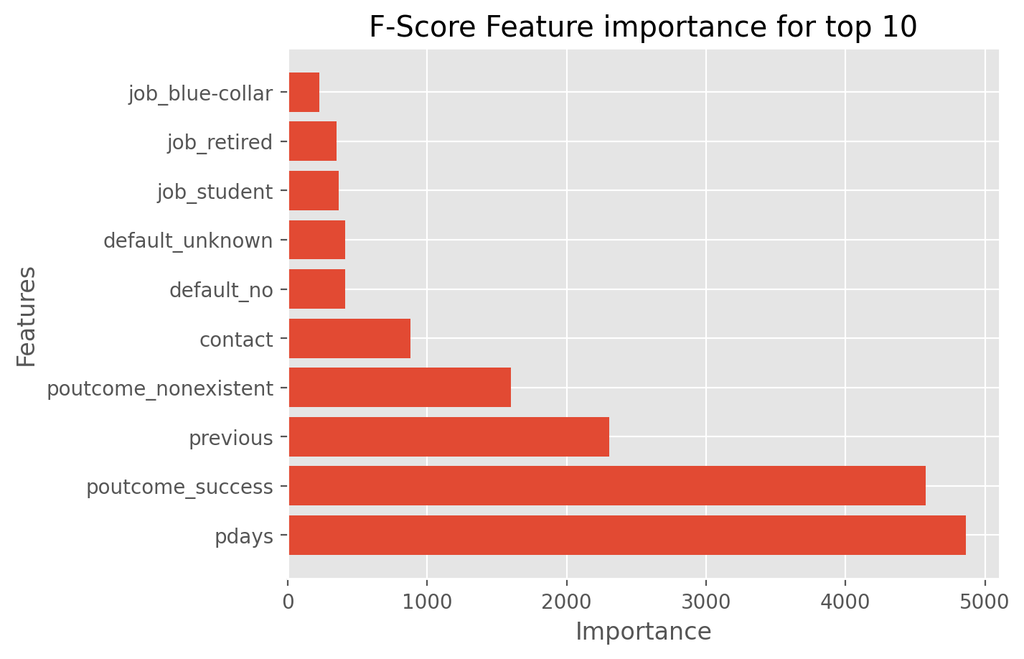

```python
def best_feat_plot(best_feat, scores, method):
    plt.barh(best_feat, scores)
    plt.title(method + ' Feature importance for top 10')
    plt.xlabel("Importance")
    plt.ylabel("Features")
    plt.show()

best_feat_plot(best_fscores, feature_imp, 'F-Score')
```

```python
fscore_results = cross_val_score(estimator=clf,
                             X=X[:, fs_indices_fscore],
                             y=y,
                             cv=cv_meth,
                             scoring=scoring_metric)

fscore_results.mean().round(3)
```

```
0.704
```

# Random forest

A Random Forest classifier was also used to determine feature importance. The top 10 features were selected based on their importance scores and visualized. The model performance using these features yielded a mean ROC-AUC score of 0.6137.

```python
from sklearn.ensemble import RandomForestClassifier

model_rfi = RandomForestClassifier(n_estimators=100)
model_rfi.fit(X, y)
fs_indices_rfi = np.argsort(model_rfi.feature_importances_)[::-1][0:num_features]

best_features = X_data.columns[fs_indices_rfi].values
best_features
```

```
array(['age', 'cons.conf.idx', 'campaign', 'pdays', 'poutcome_success',
       'previous', 'housing_no', 'contact', 'housing_yes',
       'education_high.school'], dtype=object)
```

```python
feature_importance_rfi = model_rfi.feature_importances_[fs_indices_rfi]
feature_importance_rfi
```

```
array([0.27863826, 0.21321424, 0.10787708, 0.05373614, 0.03548496,
       0.01866839, 0.01739647, 0.01700215, 0.01688845, 0.0138802 ])
```

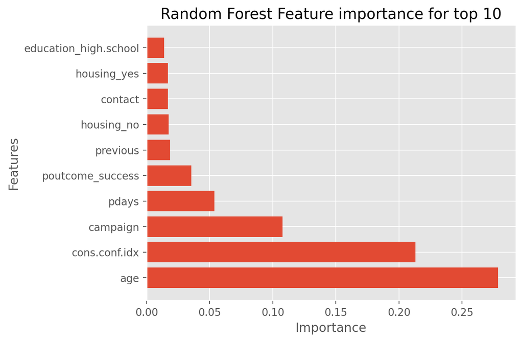

```python
def best_feat_plot(best_feat, scores, method):
    plt.barh(best_feat, scores)
    plt.title(method + ' Feature importance for top 10')
    plt.xlabel("Importance")
    plt.ylabel("Features")
    plt.show()

best_feat_plot(best_features, feature_importance_rfi, 'Random Forest')
```

```python
rfi_results = cross_val_score(estimator=clf,
                               X=X[:, fs_indices_rfi],
                               y=y,
                               cv=cv_meth,
                               scoring=scoring_metric)
rfi_results.mean().round(4)
```

```
0.6137
```

```python
print('Full Set of Features:', cv_results.mean().round(3))
print('F-Score:', fscore_results.mean().round(3))
print('RFI:', rfi_results.mean().round(4))
```

```
Full Set of Features: 0.621
F-Score: 0.704
RFI: 0.6137
```

# Model Fitting and Tuning

We evaluated several machine learning models to identify the best-performing model for our dataset. The models included:

1. Random Forest
2. Gradient Boosting
3. Support Vector Machine (SVM)
4. Gaussian Naive Bayes
5. K-Nearest Neighbors (KNN)
6. Decision Tree

```python
from sklearn.model_selection import train_test_split

X_train, X_test, y_train, y_test = train_test_split(X, y, test_size = 0.2, random_state=999, stratify=y)


print(X_test.shape)
print(X_train.shape)
```

```
(8238, 42)
(32950, 42)
```

```python
# Selecting the 10 best features

X_train_fs = X_train[:, fs_indices_fscore]
X_test_fs = X_test[:, fs_indices_fscore]
```

```python
from sklearn.neighbors import KNeighborsClassifier
from sklearn.naive_bayes import GaussianNB
from sklearn.svm import SVC
from sklearn.tree import DecisionTreeClassifier
from sklearn.ensemble import RandomForestClassifier, GradientBoostingClassifier
```

```python
from sklearn.metrics import accuracy_score, confusion_matrix, roc_auc_score, ConfusionMatrixDisplay, precision_score, recall_score, f1_score, classification_report, roc_curve, auc, precision_recall_curve, average_precision_score
from sklearn.model_selection import cross_val_score
from scikitplot.metrics import plot_roc_curve, plot_precision_recall_curve
```

```python
models = []
models.append(['Random Forest', RandomForestClassifier(random_state=0)])
models.append(['Gradient Boosting', GradientBoostingClassifier(random_state=0)])
models.append(['SVM', SVC(random_state=0)])
models.append(['GaussianNB', GaussianNB()])
models.append(['KNeigbors', KNeighborsClassifier()])
models.append(['Decision Tree', DecisionTreeClassifier(random_state=0)])
```

```python
list_1 = []

for i in range(len(models)):
    list_2= []
    model = models[i][1]
    model.fit(X_train_fs, y_train)
    y_pred = model.predict(X_test_fs)
    cm = confusion_matrix(y_test, y_pred)
    accuracies = cross_val_score(estimator = model, X = X_train_fs, y = y_train, cv = 10)   #K-Fold Validation
    roc = roc_auc_score(y_test, y_pred)
    precision = precision_score(y_test, y_pred)
    recall = recall_score(y_test, y_pred)
    f1 = f1_score(y_test, y_pred)
    print(models[i][0],':')
    print(cm)
    print('Accuracy Score: ', accuracy_score(y_test, y_pred))
    print('')
    print('K-Fold Validation Accuracy: {:.2f}%'.format(accuracies.mean()*100))
    print('')
    print('ROC AUC score: {:.2f}%'.format(roc))
    print('')
    print('Standard Deviation: {:.2f}%'.format(accuracies.std()*100))
    print('')
    print('Recall: {:.2f}%'.format(recall))
    print('')
    print('F1: {:.2f}%'.format(f1))
    print('-----------------------------')
    print('')
    list_2.append(models[i][0])
    list_2.append((accuracy_score(y_test, y_pred))*100)
    list_2.append(accuracies.mean()*100)
    list_2.append(accuracies.std()*100)
    list_2.append(roc)
    list_2.append(recall)
    list_2.append(precision)
    list_2.append(f1)
    list_1.append(list_2)
```

```
Random Forest :
[[7230   80]
 [ 767  161]]
Accuracy Score:  0.8971837824714737

K-Fold Validation Accuracy: 89.68%

ROC AUC score: 0.58%

Standard Deviation: 0.35%

Recall: 0.17%

F1: 0.28%
-----------------------------

Gradient Boosting :
[[7214   96]
 [ 746  182]]
Accuracy Score:  0.8977907259043457

K-Fold Validation Accuracy: 89.78%

ROC AUC score: 0.59%

Standard Deviation: 0.35%

Recall: 0.20%

F1: 0.30%
-----------------------------

SVM :
[[7214   96]
 [ 762  166]]
Accuracy Score:  0.8958485069191552

K-Fold Validation Accuracy: 89.72%

ROC AUC score: 0.58%
```

[output cut: 40 more lines]

```
Decision Tree :
[[7230   80]
 [ 771  157]]
Accuracy Score:  0.896698227725176

K-Fold Validation Accuracy: 89.69%

ROC AUC score: 0.58%

Standard Deviation: 0.35%

Recall: 0.17%

F1: 0.27%
-----------------------------
```

```python
df= pd.DataFrame(list_1, columns = ['Model', 'Accuracy', 'K-Fold Mean Accuracy', 'Std. Deviation', 'ROC AUC', 'Precision', 'Recall', 'F1'])
df.sort_values(by=['Accuracy', 'K-Fold Mean Accuracy'], inplace=True, ascending=False)
df
```

[output not shown]

# Tuning

```python
from sklearn.model_selection import GridSearchCV

params_RF = {'n_estimators':[100, 200, 300], 'criterion':['gini', 'entropy'], 'random_state':[0], 'max_depth': [5, 7, 9, 12]}
grid_RF = GridSearchCV(estimator=RandomForestClassifier(random_state=999), param_grid = params_RF, scoring = 'roc_auc', cv = cv_meth)
grid_RF.fit(X_train_fs, y_train)
best_acc = grid_RF.best_score_
best_param = grid_RF.best_params_
print('{}:\nBest Accuracy: {:.2f}%'.format(RandomForestClassifier(),best_acc*100))
print('Best Parameters : ',best_param)
print('')
print('-----------------------------')
```

```
RandomForestClassifier():
Best Accuracy: 71.46%
Best Parameters :  {'criterion': 'gini', 'max_depth': 5, 'n_estimators': 300, 'random_state': 0}

-----------------------------
```

```python
RF_results = pd.DataFrame(grid_RF.cv_results_['params'])
RF_results['Test_score'] = grid_RF.cv_results_['mean_test_score']
RF_results
```

|  | criterion | max_depth | n_estimators | random_state | Test_score |
| --- | --- | --- | --- | --- | --- |
| 0 | gini | 5 | 100 | 0 | 0.714608 |
| 1 | gini | 5 | 200 | 0 | 0.714575 |
| 2 | gini | 5 | 300 | 0 | 0.714608 |
| 3 | gini | 7 | 100 | 0 | 0.714128 |
| 4 | gini | 7 | 200 | 0 | 0.714078 |
| 5 | gini | 7 | 300 | 0 | 0.714113 |
| 6 | gini | 9 | 100 | 0 | 0.713057 |
| 7 | gini | 9 | 200 | 0 | 0.713101 |
| 8 | gini | 9 | 300 | 0 | 0.713028 |
| 9 | gini | 12 | 100 | 0 | 0.711420 |
| 10 | gini | 12 | 200 | 0 | 0.711689 |
| 11 | gini | 12 | 300 | 0 | 0.711582 |
| 12 | entropy | 5 | 100 | 0 | 0.714408 |
| 13 | entropy | 5 | 200 | 0 | 0.714335 |
| 14 | entropy | 5 | 300 | 0 | 0.714209 |
| 15 | entropy | 7 | 100 | 0 | 0.714192 |
| 16 | entropy | 7 | 200 | 0 | 0.714112 |
| 17 | entropy | 7 | 300 | 0 | 0.714103 |
| 18 | entropy | 9 | 100 | 0 | 0.713159 |
| 19 | entropy | 9 | 200 | 0 | 0.713133 |
| 20 | entropy | 9 | 300 | 0 | 0.713101 |
| 21 | entropy | 12 | 100 | 0 | 0.711560 |
| 22 | entropy | 12 | 200 | 0 | 0.711746 |
| 23 | entropy | 12 | 300 | 0 | 0.711669 |

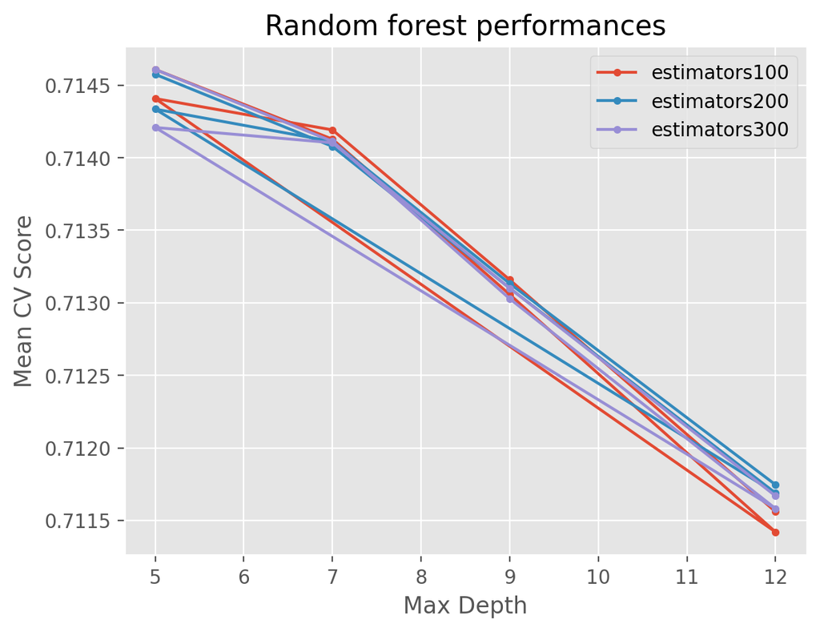

```python
for i in RF_results['n_estimators'].unique():
    results = RF_results[RF_results['n_estimators'] == i]
    plt.plot(results['max_depth'], results['Test_score'], marker='.', label='estimators' +str(i))

plt.legend()
plt.xlabel('Max Depth')
plt.ylabel('Mean CV Score')
plt.title('Random forest performances')
plt.show()
```

# Gradient Boosting

```python
gradient_params = {
    'n_estimators': [100, 200, 300],
    'learning_rate': [0.01, 0.1, 0.2],
    'max_depth': [3, 5, 7],
    'random_state': [0]
}

# Initialize the GridSearchCV object
grid_GB = GridSearchCV(estimator=GradientBoostingClassifier(random_state=999), param_grid=gradient_params, scoring='roc_auc', cv=cv_meth)

# Fit the model
grid_GB.fit(X_train_fs, y_train)

# Get the best score and parameters
best_acc_GB = grid_GB.best_score_
best_param_GB = grid_GB.best_params_

# Print the results
print('{}:\nBest Accuracy: {:.2f}%'.format(GradientBoostingClassifier(), best_acc_GB * 100))
print('Best Parameters : ', best_param_GB)
print('')
print('-----------------------------')
```

```
GradientBoostingClassifier():
Best Accuracy: 71.48%
Best Parameters :  {'learning_rate': 0.1, 'max_depth': 3, 'n_estimators': 100, 'random_state': 0}

-----------------------------
```

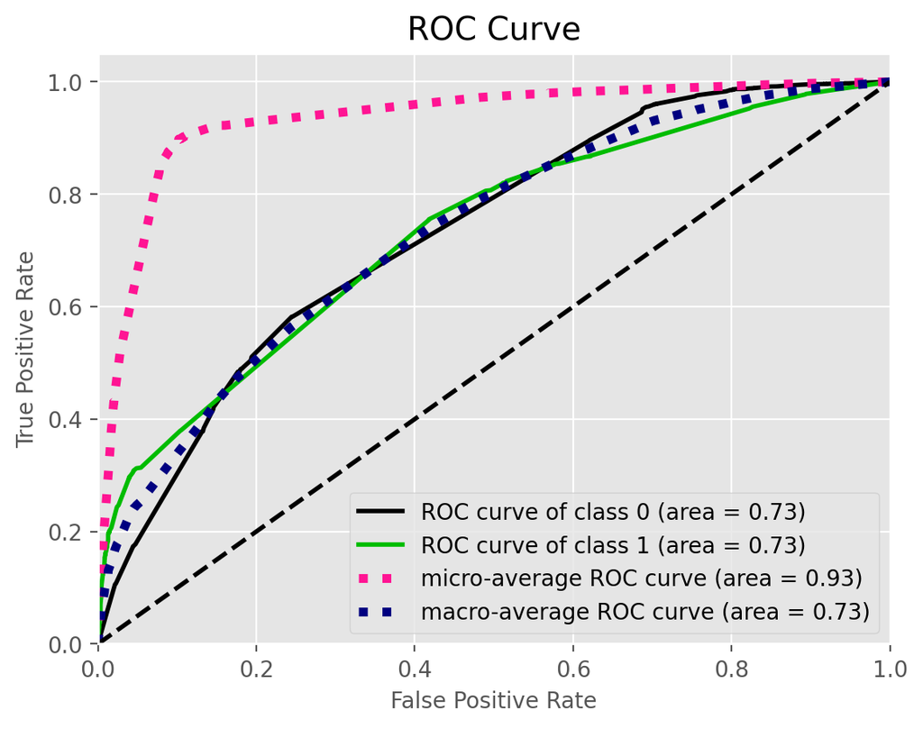

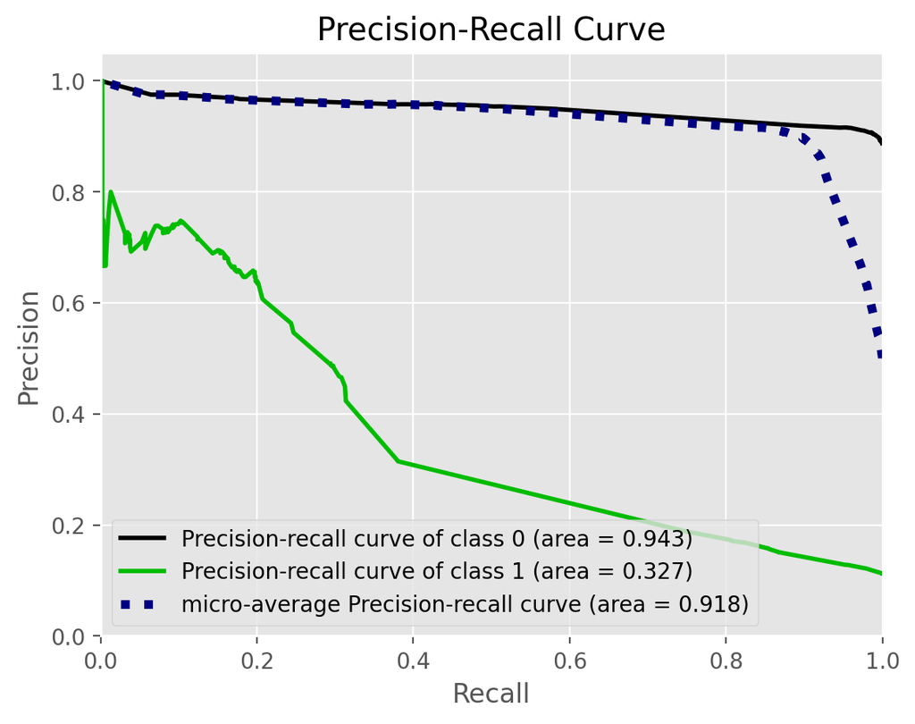

```python
from sklearn.metrics import accuracy_score, confusion_matrix, roc_auc_score, ConfusionMatrixDisplay, precision_score, recall_score, f1_score, classification_report, roc_curve, auc, precision_recall_curve, average_precision_score
from sklearn.model_selection import cross_val_score, GridSearchCV
from sklearn.ensemble import GradientBoostingClassifier
import scikitplot as skplt
import matplotlib.pyplot as plt
y_pred_proba = grid_GB.predict_proba(X_test_fs)

# Plot the ROC curve
skplt.metrics.plot_roc(y_test, y_pred_proba)
plt.title('ROC Curve')
plt.show()

# Plot the Precision-Recall curve
skplt.metrics.plot_precision_recall(y_test, y_pred_proba)
plt.title('Precision-Recall Curve')
plt.show()
```

```python
gradient_results = pd.DataFrame(grid_GB.cv_results_['params'])
gradient_results['Test_score'] = grid_GB.cv_results_['mean_test_score']
gradient_results
```

|  | learning_rate | max_depth | n_estimators | random_state | Test_score |
| --- | --- | --- | --- | --- | --- |
| 0 | 0.01 | 3 | 100 | 0 | 0.707008 |
| 1 | 0.01 | 3 | 200 | 0 | 0.712116 |
| 2 | 0.01 | 3 | 300 | 0 | 0.714667 |
| 3 | 0.01 | 5 | 100 | 0 | 0.710255 |
| 4 | 0.01 | 5 | 200 | 0 | 0.712395 |
| 5 | 0.01 | 5 | 300 | 0 | 0.713137 |
| 6 | 0.01 | 7 | 100 | 0 | 0.710366 |
| 7 | 0.01 | 7 | 200 | 0 | 0.711085 |
| 8 | 0.01 | 7 | 300 | 0 | 0.711122 |
| 9 | 0.10 | 3 | 100 | 0 | 0.714766 |
| 10 | 0.10 | 3 | 200 | 0 | 0.714342 |
| 11 | 0.10 | 3 | 300 | 0 | 0.713191 |
| 12 | 0.10 | 5 | 100 | 0 | 0.712427 |
| 13 | 0.10 | 5 | 200 | 0 | 0.709378 |
| 14 | 0.10 | 5 | 300 | 0 | 0.706538 |
| 15 | 0.10 | 7 | 100 | 0 | 0.706820 |
| 16 | 0.10 | 7 | 200 | 0 | 0.702615 |
| 17 | 0.10 | 7 | 300 | 0 | 0.701429 |
| 18 | 0.20 | 3 | 100 | 0 | 0.713803 |
| 19 | 0.20 | 3 | 200 | 0 | 0.712548 |
| 20 | 0.20 | 3 | 300 | 0 | 0.711808 |
| 21 | 0.20 | 5 | 100 | 0 | 0.709182 |
| 22 | 0.20 | 5 | 200 | 0 | 0.704009 |
| 23 | 0.20 | 5 | 300 | 0 | 0.702200 |
| 24 | 0.20 | 7 | 100 | 0 | 0.702320 |
| 25 | 0.20 | 7 | 200 | 0 | 0.701414 |
| 26 | 0.20 | 7 | 300 | 0 | 0.700770 |

# GaussianNB

```python
np.random.seed(999)
GB_params = {'var_smoothing':np.logspace(1, -3, num=200)}
grid_GB = GridSearchCV(estimator=GaussianNB(), param_grid = GB_params, scoring='roc_auc', cv=cv_meth)
grid_GB.fit(X_train_fs, y_train)
best_acc = grid_GB.best_score_
best_param = grid_GB.best_params_
print('{}:\nBest Accuracy : {:.2f}%'.format(GaussianNB(),best_acc*100))
print('Best Parameters : ',best_param)
print('')
print('----------------')
print('')
```

```
GaussianNB():
Best Accuracy : 71.05%
Best Parameters :  {'var_smoothing': 0.22478058335487253}

----------------
```

```python
GB_results = pd.DataFrame(grid_GB.cv_results_['params'])
GB_results['test_score'] = grid_GB.cv_results_['mean_test_score']
```

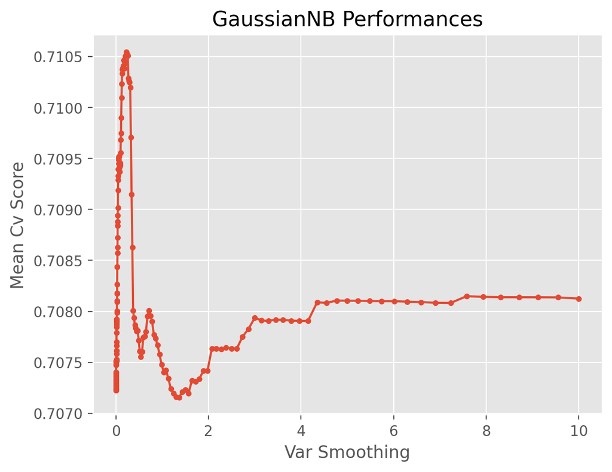

```python
plt.plot(GB_results['var_smoothing'], GB_results['test_score'], marker='.')
plt.xlabel('Var Smoothing')
plt.ylabel('Mean Cv Score')
plt.title('GaussianNB Performances')
plt.show()
```

## KNN Hyperparameters

```python
from sklearn.model_selection import GridSearchCV
parameters_knn = {'n_neighbors':[3,5,7,9], 'metric':['euclidean', 'manhattan', 'minkowski']}
grid_knn = GridSearchCV(estimator=KNeighborsClassifier(), param_grid = parameters_knn, scoring = 'accuracy', cv=10)
grid_knn.fit(X_train_fs, y_train)
best_acc = grid_knn.best_score_
best_param = grid_knn.best_params_
print('{}:\nBest accuracy is : {:.2f}%'.format(KNeighborsClassifier(), best_acc*100))
print('Best Parameters: ', best_param)
print('')
print('-------------------')
```

```
KNeighborsClassifier():
Best accuracy is : 87.28%
Best Parameters:  {'metric': 'euclidean', 'n_neighbors': 9}

-------------------
```

```python
KNN_results = pd.DataFrame(grid_knn.cv_results_['params'])
KNN_results['Test_score'] = grid_knn.cv_results_['mean_test_score']
KNN_results
```

|  | metric | n_neighbors | Test_score |
| --- | --- | --- | --- |
| 0 | euclidean | 3 | 0.837147 |
| 1 | euclidean | 5 | 0.847557 |
| 2 | euclidean | 7 | 0.871866 |
| 3 | euclidean | 9 | 0.872777 |
| 4 | manhattan | 3 | 0.837147 |
| 5 | manhattan | 5 | 0.847557 |
| 6 | manhattan | 7 | 0.871866 |
| 7 | manhattan | 9 | 0.872777 |
| 8 | minkowski | 3 | 0.837147 |
| 9 | minkowski | 5 | 0.847557 |
| 10 | minkowski | 7 | 0.871866 |
| 11 | minkowski | 9 | 0.872777 |

```
Values for all three Hyperparameters are same, so only one line is shown in the graph below.
```

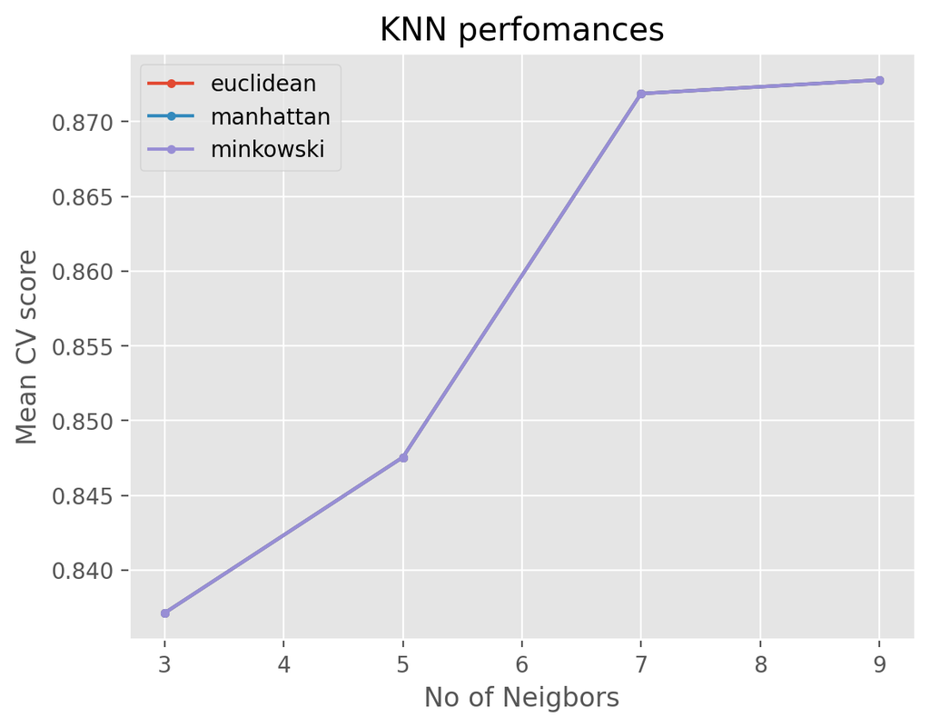

```python
for i in KNN_results['metric'].unique():
    result = KNN_results[KNN_results['metric'] == i]
    plt.plot(result['n_neighbors'], result['Test_score'], marker='.', label=i)

print("Values for all three Hyperparameters are same, so only one line is shown in the graph below.")
print("")

plt.legend()
plt.xlabel("No of Neigbors")
plt.ylabel("Mean CV score")
plt.title("KNN perfomances")
plt.show()
```

# Decision Tree

```python
Decision_params = {'criterion':['entropy', 'gini'], 'random_state':[0], 'max_depth': [1, 2, 3, 4, 5, 6, 7, 8, ], 'min_samples_split':[2,3]}

grid_dec = GridSearchCV(estimator=DecisionTreeClassifier(), param_grid = Decision_params, scoring = 'accuracy', cv=10)
grid_dec.fit(X_train_fs, y_train)
best_acc = grid_dec.best_score_
best_param = grid_dec.best_params_
print('{}:\nBest Accuracy: {:2f}%'.format(DecisionTreeClassifier(), best_acc*100))
print('Best Parameters : ', best_param)
print('')
print('-----------------------------')
```

```
DecisionTreeClassifier():
Best Accuracy: 89.796662%
Best Parameters :  {'criterion': 'entropy', 'max_depth': 4, 'min_samples_split': 2, 'random_state': 0}

-----------------------------
```

```python
dec_results = pd.DataFrame(grid_dec.cv_results_['params'])
dec_results['test_score'] = grid_dec.cv_results_['mean_test_score']

dec_results
```

|  | criterion | max_depth | min_samples_split | random_state | test_score |
| --- | --- | --- | --- | --- | --- |
| 0 | entropy | 1 | 2 | 0 | 0.897633 |
| 1 | entropy | 1 | 3 | 0 | 0.897633 |
| 2 | entropy | 2 | 2 | 0 | 0.897269 |
| 3 | entropy | 2 | 3 | 0 | 0.897269 |
| 4 | entropy | 3 | 2 | 0 | 0.897329 |
| 5 | entropy | 3 | 3 | 0 | 0.897329 |
| 6 | entropy | 4 | 2 | 0 | 0.897967 |
| 7 | entropy | 4 | 3 | 0 | 0.897967 |
| 8 | entropy | 5 | 2 | 0 | 0.897785 |
| 9 | entropy | 5 | 3 | 0 | 0.897754 |
| 10 | entropy | 6 | 2 | 0 | 0.897876 |
| 11 | entropy | 6 | 3 | 0 | 0.897876 |
| 12 | entropy | 7 | 2 | 0 | 0.897754 |
| 13 | entropy | 7 | 3 | 0 | 0.897754 |
| 14 | entropy | 8 | 2 | 0 | 0.897602 |
| 15 | entropy | 8 | 3 | 0 | 0.897602 |
| 16 | gini | 1 | 2 | 0 | 0.897633 |
| 17 | gini | 1 | 3 | 0 | 0.897633 |
| 18 | gini | 2 | 2 | 0 | 0.897269 |
| 19 | gini | 2 | 3 | 0 | 0.897269 |
| 20 | gini | 3 | 2 | 0 | 0.897360 |
| 21 | gini | 3 | 3 | 0 | 0.897360 |
| 22 | gini | 4 | 2 | 0 | 0.897936 |
| 23 | gini | 4 | 3 | 0 | 0.897936 |
| 24 | gini | 5 | 2 | 0 | 0.897754 |
| 25 | gini | 5 | 3 | 0 | 0.897754 |
| 26 | gini | 6 | 2 | 0 | 0.897845 |
| 27 | gini | 6 | 3 | 0 | 0.897815 |
| 28 | gini | 7 | 2 | 0 | 0.897511 |
| 29 | gini | 7 | 3 | 0 | 0.897481 |
| 30 | gini | 8 | 2 | 0 | 0.897481 |
| 31 | gini | 8 | 3 | 0 | 0.897451 |

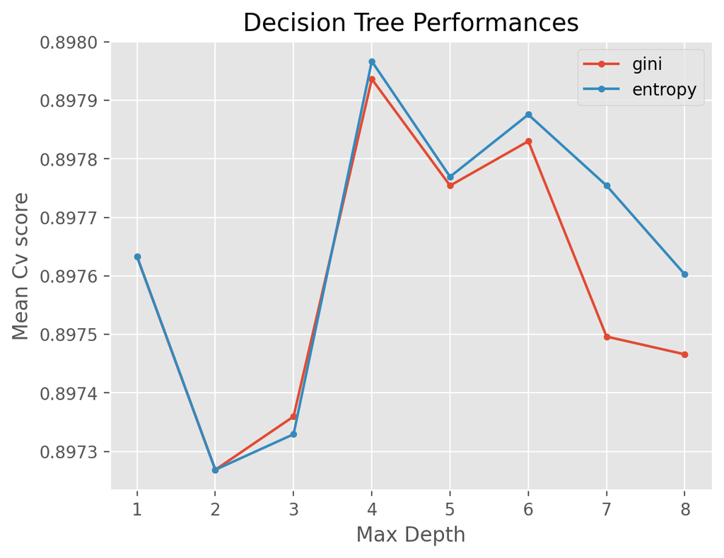

```python
for i in ['gini', 'entropy']:
    results = dec_results[dec_results['criterion']==i]
    results_average = results.groupby('max_depth').agg({'test_score':'mean'})
    plt.plot(results_average, marker='.', label=i)

plt.legend()
plt.xlabel('Max Depth')
plt.ylabel('Mean Cv score')
plt.title('Decision Tree Performances')
plt.show()
```

# Model Comparison

```python
ttest_cv_method = StratifiedKFold(n_splits=10)
```

```python
RF_results = cross_val_score(estimator=grid_RF.best_estimator_,
                                        X=X_test_fs,
                                        y=y_test,
                                        cv=ttest_cv_method,
                                        n_jobs=2,
                                        scoring='roc_auc')
RF_results.mean()
```

```
0.7281394357540791
```

```python
DT_results = cross_val_score(estimator=grid_dec.best_estimator_,
                                X=X_test_fs,
                                y=y_test,
                                cv=ttest_cv_method,
                                n_jobs=-2,
                                scoring='roc_auc')
DT_results.mean()
```

```
0.7024590066954078
```

```python
gradient_results = cross_val_score(estimator=grid_dec.best_estimator_,
                                X=X_test_fs,
                                y=y_test,
                                cv=ttest_cv_method,
                                n_jobs=-2,
                                scoring='roc_auc')

gradient_results.mean()
```

```
0.7024590066954078
```

```python
from sklearn.preprocessing import PowerTransformer

X_test_transformed_fs = PowerTransformer().fit_transform(X_test_fs)

GB_results = cross_val_score(estimator=grid_GB.best_estimator_,
                                X=X_test_transformed_fs,
                                y=y_test,
                                cv=ttest_cv_method,
                                n_jobs=-2,
                                scoring='roc_auc')
GB_results.mean()
```

```
0.7229520215731682
```

```python
KNN_results = cross_val_score(estimator=grid_knn.best_estimator_,
                                 X=X_test_fs,
                                 y=y_test,
                                 cv=ttest_cv_method,
                                 n_jobs=-2,
                                 scoring='roc_auc')
KNN_results.mean()
```

```
0.7031177151704806
```

```python
from scipy import stats

print(stats.ttest_rel(KNN_results, DT_results))
print(stats.ttest_rel(KNN_results, GB_results))
print(stats.ttest_rel(DT_results, GB_results))

print(stats.ttest_rel(RF_results, DT_results))
print(stats.ttest_rel(RF_results, KNN_results))
print(stats.ttest_rel(RF_results, GB_results))

print(stats.ttest_rel(gradient_results, DT_results))
print(stats.ttest_rel(gradient_results, KNN_results))
print(stats.ttest_rel(gradient_results, GB_results))
print(stats.ttest_rel(gradient_results, RF_results))
```

```
TtestResult(statistic=0.057751385962842954, pvalue=0.9552085557640286, df=9)
TtestResult(statistic=-1.707379082400156, pvalue=0.1219321429791357, df=9)
TtestResult(statistic=-3.8410910249582075, pvalue=0.00395991146080318, df=9)
TtestResult(statistic=5.110367327599408, pvalue=0.0006361878099926752, df=9)
TtestResult(statistic=2.900991280477381, pvalue=0.01756699709304778, df=9)
TtestResult(statistic=1.505886892558379, pvalue=0.16635946877965938, df=9)
TtestResult(statistic=nan, pvalue=nan, df=9)
TtestResult(statistic=-0.057751385962842954, pvalue=0.9552085557640286, df=9)
TtestResult(statistic=-3.8410910249582075, pvalue=0.00395991146080318, df=9)
TtestResult(statistic=-5.110367327599408, pvalue=0.0006361878099926752, df=9)
```

# Critique & Limitations

### Limitations

1. Imbalanced Dataset: The imbalance in the dataset was one of the main drawbacks. The target variable, which indicated whether or not a client had a term deposit, was skewed, with non-subscribers making up the bulk of the cases. Models that are biased in favor of the majority class may result from this imbalance. Future work might benefit from methods particularly developed to handle unbalanced datasets, including class-weight modifications or SMOTE (Synthetic Minority Over-sampling Technique). This is even if assessment techniques like ROC-AUC are still being used.
2. Computational Intensity:Some models required a lot of computing power because of the large dimensionality of the data, especially the K-Nearest Neighbors (KNN). Because KNN needs to calculate the distance between each pair of instances, it is known to be sluggish when dealing with huge datasets.
3. Overfitting Risk: Extensive hyperparameter tuning always carries the risk of overfitting, in which the model excels on training data but is unable to generalize to new data. While cross-validation reduces this risk, in order to guarantee the model's generalizability, it is essential to validate it on an entirely separate test set.
4. Model Interpretability: Certain models, like Random Forests and Decision Trees, may be somewhat interpreted, while other models, like Support Vector Machines, are frequently referred to as "black boxes." When attempting to explain the model's judgments to stakeholders or regulatory agencies, this lack of transparency may be a hindrance.
5. Feature Engineering: Even with our thorough feature selection, more feature engineering can enhance the performance of the model even more. For example, generating polynomial features or interaction terms might help identify more intricate correlations in the data. Nevertheless, this might exacerbate computing difficulties by adding to the models' dimensions and complexity.
6. Temporal Data Issues: Although the dataset lacks explicit time-series data, temporal connections may be introduced by some variables (such as the month of contact). Ignoring them might result in models that are unable to accurately represent changes over time or seasonal trends. More study might investigate openly adding temporal factors.
7. Economic Indicators: A number of economic variables that may have changed dramatically over time were included in the dataset. The dynamic character of these indicators might not be well captured by static models. For deeper insights, a more dynamic modeling technique that could incorporate time-series analysis could be helpful.
8. Scalability: Scalability would need to be taken into account when implementing these models in a real-world setting. The KNN model in particular may require high-performance computer resources because to its computational intensity. Furthermore, for real-time applications, the delay in predicting using models such as KNN must be addressed.

# Future Work

Future research may look at the following to solve these limitations:

1. Applying advanced methods, such ensemble methods or anomaly detection procedures, to deal with unbalanced data.
2. Investigating more effective approximations or techniques for models with high computing demands.
3. To guarantee generalizability, more thorough validation should be carried out using totally separate datasets.
4. Improving the interpretability of the model by using methods such as LIME (Local Interpretable Model-agnostic Explanations) or SHAP (SHapley Additive exPlanations).
5. Adding more feature engineering and temporal analysis to the data in order to identify more intricate patterns.

We may improve our prediction models' robustness and suitability for use in actual marketing campaigns by resolving these issues.

# Summary & Conclusion

## Project Summary

Our goal in this research was to use campaign-related and demographic data to forecast a client's likelihood of subscribing to a term deposit. The project was split into two independent phases, each with its own set of objectives and working methods.

### Phase 1

1. Data Cleaning: The first phase in the process was data cleaning, which required dealing with inconsistent data, removing unnecessary columns, and filling in any missing information. To make numerical variables acceptable for modeling, they were scaled and categorical variables were encoded.
2. Exploratory Data analysis: In order to comprehend the structure of the dataset and pinpoint important trends, we conducted an exploratory study. This involved putting distributions, correlations, and feature-to-target variable linkages on display. To learn more about the data, we employed methods like pair plots and correlation heatmaps.
3. Feature Engineering: To improve the models' capacity for prediction, new features were created. We modified the original dataset's characteristics and added new ones to capture crucial information that was missing.

### Conclusion

Based on our goals and objectives, we can draw several comprehensive conclusions from this project:

All things considered, this experiment proved that utilizing machine learning techniques to forecast consumer behavior in marketing campaigns is both feasible and successful. Financial institutions may enhance consumer interaction, optimize marketing efforts, and ultimately achieve better business outcomes with the aid of the insights gleaned from this investigation.